# Exploring the Financial Contributions made by Wisconsin for 2012 Presidential Elections - by Umesh

## Loading the data, adding or modifying and getting the feel of the contents of the dataset.

```
## [1] 69304    18
```

```
## 'data.frame':    69304 obs. of  18 variables:
##  $ cmte_id          : Factor w/ 15 levels "C00410118","C00431171",..: 2 2 2 2 2 2 2 2 2 2 ...
##  $ cand_id          : Factor w/ 14 levels "P00003608","P20002523",..: 14 14 14 14 14 14 14 14 14 14 ...
##  $ cand_nm          : Factor w/ 14 levels "Bachmann, Michele",..: 12 12 12 12 12 12 12 12 12 12 ...
##  $ contbr_nm        : Factor w/ 18937 levels "''LEONARD,'', BARBARA MS.",..: 16144 16171 16491 16498 17175 17179 17193 17194 17202 17202 ...
##  $ contbr_city      : Factor w/ 798 levels "- SELECT A VALUE -",..: 218 754 23 422 459 459 244 423 596 596 ...
##  $ contbr_st        : Factor w/ 1 level "WI": 1 1 1 1 1 1 1 1 1 1 ...
##  $ contbr_zip       : Factor w/ 12210 levels "200165064","22407",..: 2212 1840 11703 5925 3523 3524 2360 9831 6325 6325 ...
##  $ contbr_employer  : Factor w/ 7180 levels "","--"," WAUKESHA SCHOOL DISTRICT",..: 3813 2779 5344 4941 2823 2823 2823 3633 4941 4941 ...
##  $ contbr_occupation: Factor w/ 4137 levels "","--"," PUBLIC HEALTH",..: 2269 3327 1441 3155 1799 1799 1799 2623 3155 3155 ...
##  $ contb_receipt_amt: num  250 750 100 500 2500 2500 220 500 10 21 ...
##  $ contb_receipt_dt : Factor w/ 628 levels "1-Apr-12","1-Aug-11",..: 149 45 493 149 413 413 86 86 592 493 ...
##  $ receipt_desc     : Factor w/ 16 levels "","REATTRIBUTED",..: 1 1 1 1 1 1 1 1 1 1 ...
##  $ memo_cd          : Factor w/ 2 levels "","X": 1 1 1 1 1 1 1 1 1 1 ...
##  $ memo_text        : Factor w/ 58 levels "","*","* EARMARKED CONTRIBUTION: SEE BELOW",..: 1 1 1 1 1 1 1 1 1 1 ...
##  $ form_tp          : Factor w/ 3 levels "SA17A","SA18",..: 1 1 1 1 1 1 1 1 1 1 ...
##  $ file_num         : int  896743 896743 896743 896743 896743 896743 896743 896743 896743 896743 ...
##  $ tran_id          : Factor w/ 69297 levels "0027035-0001",..: 56848 56694 57288 56911 57291 57292 56735 56761 56656 57377 ...
##  $ election_tp.     : Factor w/ 7 levels "","G2008","G2012",..: 3 7 3 7 7 7 7 7 7 3 ...
```

```
##     cmte_id   cand_id      cand_nm               contbr_nm contbr_city
## 1 C00431171 P80003353 Romney, Mitt            STEIN, MERYL   ELM GROVE
## 2 C00431171 P80003353 Romney, Mitt        STELLMACHER, TIM   WEST BEND
## 3 C00431171 P80003353 Romney, Mitt SUPRISE, PATRICK R. MR.    APPLETON
##   contbr_st contbr_zip contbr_employer contbr_occupation contb_receipt_amt
## 1        WI  531221840     MERYL STEIN       MERYL STEIN               250
## 2        WI  530955528       IGUS INC.     SALES MANAGER               750
## 3        WI  549148221   SELF-EMPLOYED FINANCIAL PLANNER               100
##   contb_receipt_dt receipt_desc memo_cd memo_text form_tp file_num
## 1        16-Aug-12                                  SA17A   896743
## 2        11-Aug-12                                  SA17A   896743
## 3        31-Aug-12                                  SA17A   896743
##        tran_id election_tp.
## 1 SA17.2030529        G2012
## 2 SA17.1878735        P2012
## 3 SA17.2224856        G2012
```

#### Observations from the initial look into the dataset:

- There are 69304 observations with 18 variables in the dataset.
- All are categorical variables except the contb_receipt_amt and file_num variable.

This is a interesting data set and would be interesting to find:

- Who contributed most ?
- Which city in Wisconsin contributed more and to whom?
- Which candidate got the highest contribution?
- Which party got the highest and which party got the least?
- Are there any female candidates and how did they perform?

In order to answer few of the above questions, need to add couple of more attributes like gender and party of the candiate.

### Creating new variables and modifying the existing variable values

#### Adding Party Variable

```
##
##                    Democratic Party                         Green Party
##                               52604                                  47
##                   Libertarian Party                    Republican Party
##                                  60                               16508
## Republican,Reform & Americans Elect
##                                  85
```

```
##     cmte_id   cand_id      cand_nm               contbr_nm contbr_city
## 1 C00431171 P80003353 Romney, Mitt            STEIN, MERYL   ELM GROVE
## 2 C00431171 P80003353 Romney, Mitt        STELLMACHER, TIM   WEST BEND
## 3 C00431171 P80003353 Romney, Mitt SUPRISE, PATRICK R. MR.    APPLETON
##   contbr_st contbr_zip contbr_employer contbr_occupation contb_receipt_amt
## 1        WI  531221840     MERYL STEIN       MERYL STEIN               250
## 2        WI  530955528       IGUS INC.     SALES MANAGER               750
## 3        WI  549148221   SELF-EMPLOYED FINANCIAL PLANNER               100
##   contb_receipt_dt receipt_desc memo_cd memo_text form_tp file_num
## 1        16-Aug-12                                  SA17A   896743
## 2        11-Aug-12                                  SA17A   896743
## 3        31-Aug-12                                  SA17A   896743
##        tran_id election_tp.            party
## 1 SA17.2030529        G2012 Republican Party
## 2 SA17.1878735        P2012 Republican Party
## 3 SA17.2224856        G2012 Republican Party
```

#### Adding Gender Variable

```
##
## Female   Male
##    195  69109
```

```
##     cmte_id   cand_id      cand_nm               contbr_nm contbr_city
## 1 C00431171 P80003353 Romney, Mitt            STEIN, MERYL   ELM GROVE
## 2 C00431171 P80003353 Romney, Mitt        STELLMACHER, TIM   WEST BEND
## 3 C00431171 P80003353 Romney, Mitt SUPRISE, PATRICK R. MR.    APPLETON
##   contbr_st contbr_zip contbr_employer contbr_occupation contb_receipt_amt
## 1        WI  531221840     MERYL STEIN       MERYL STEIN               250
## 2        WI  530955528       IGUS INC.     SALES MANAGER               750
## 3        WI  549148221   SELF-EMPLOYED FINANCIAL PLANNER               100
##   contb_receipt_dt receipt_desc memo_cd memo_text form_tp file_num
## 1        16-Aug-12                                  SA17A   896743
## 2        11-Aug-12                                  SA17A   896743
## 3        31-Aug-12                                  SA17A   896743
##        tran_id election_tp.            party gender
## 1 SA17.2030529        G2012 Republican Party   Male
## 2 SA17.1878735        P2012 Republican Party   Male
## 3 SA17.2224856        G2012 Republican Party   Male
```

#### Modifying contbr_zip Variable

- Value of the contbr_zip variable which is the zip code of the places are not uniform five digit numbers.
- Having them uniform and clean should very useful for exploring. So modifying the values of the contbr_zip variable to uniform five digit codes by extracting only the first five digits.
- This should help us to find people from which zip code contributed most.

#### Top 5 Zip codes in terms of contributions count

```
##
## 53711 53705 53211 53217 53704
##  2997  2491  1942  1526  1450
```

#### Converting the date variable into Date type

- This date variable should help us to explore the variation in the contribution over time.
- Having it converted should help us get more insight

#### Summary of the dataset:

```
##       cmte_id           cand_id                cand_nm
##  C00431445:52604   P80003338:52604   Obama, Barack :52604
##  C00431171:12537   P80003353:12537   Romney, Mitt  :12537
##  C00495820: 2270   P80000748: 2270   Paul, Ron     : 2270
##  C00496034:  740   P20002721:  740   Santorum, Rick:  740
##  C00496497:  403   P60003654:  403   Gingrich, Newt:  403
##  C00496067:  258   P00003608:  258   Cain, Herman  :  258
##  (Other)  :  492   (Other)  :  492   (Other)       :  492
##             contbr_nm        contbr_city    contbr_st   contbr_zip
##  ANDERSON, TERESA:   98   MADISON  :10874   WI:69304   Length:69304
##  VOLZ, WILLIAM   :   88   MILWAUKEE: 7849              Class :character
##  SILVERMAN, CARL :   83   RACINE   : 1412              Mode  :character
##  KURTH, ED       :   74   MIDDLETON: 1323
##  PORASIK, NANCY  :   71   GREEN BAY: 1208
##  OXHOLM, BARBARA :   70   WAUKESHA : 1185
##  (Other)         :68820   (Other)  :45453
##                                contbr_employer
##  RETIRED                               :17267
##  SELF-EMPLOYED                         : 5444
##  NOT EMPLOYED                          : 5129
##  INFORMATION REQUESTED                 : 1934
##  INFORMATION REQUESTED PER BEST EFFORTS: 1709
##  (Other)                               :37793
##  NA's                                  :   28
##                               contbr_occupation contb_receipt_amt
##  RETIRED                               :19351   Min.   :-5000.0
##  PHYSICIAN                             : 1942   1st Qu.:   25.0
##  INFORMATION REQUESTED                 : 1733   Median :   50.0
##  INFORMATION REQUESTED PER BEST EFFORTS: 1643   Mean   :  154.6
##  ATTORNEY                              : 1630   3rd Qu.:  100.0
##  (Other)                               :42993   Max.   : 7500.0
##  NA's                                  :   12
##  contb_receipt_dt                                      receipt_desc
##  Min.   :2011-01-01                                          :68585
##  1st Qu.:2012-06-28   Refund                                 :  525
##  Median :2012-09-13   REDESIGNATION FROM PRIMARY             :   38
##  Mean   :2012-07-29   REDESIGNATION TO GENERAL               :   38
##  3rd Qu.:2012-10-16   REATTRIBUTION / REDESIGNATION REQUESTED:   22
##  Max.   :2012-12-31   REATTRIBUTION FROM SPOUSE              :   22
##                       (Other)                                :   74
```

[output cut: 9 more lines]

```
##  Min.   :736038   0027035-0001 :    2        :    9
##  1st Qu.:876050   0027035-REATT:    2   G2008:    6
##  Median :896785   27035        :    2   G2012:38285
##  Mean   :881589   SA17.1169380 :    2   O2012:   33
##  3rd Qu.:897086   SA17.1674820 :    2   P    :    3
##  Max.   :921959   SA17.4343754 :    2   P2008:    8
##                   (Other)      :69292   P2012:30960
##                                  party          gender
##  Democratic Party                   :52604   Female:  195
##  Green Party                        :   47   Male  :69109
##  Libertarian Party                  :   60
##  Republican Party                   :16508
##  Republican,Reform & Americans Elect:   85
##
##
```

#### Highlights from the Summary:

- Barack Obama is the candidate with highest number of contributions.
- City of Madison has highest number of contributions with Milwaukee coming second.
- Retired people are highest contributors by occupation.
- Least amount contributed is negative -5000 and maximum is 7500.
- Democratic Party getting the highest number of contributions with Republican party coming second by huge difference.
- There is only one female candidate who has very less number contributions.
- There are some records which are for 2008 elections and some do not seem to belong to any.
- General elections of 2012 have recieved more contributions than Primary elections.

Questions arising after viewing the summary of the dataset:

- Even though Obama had highest number of contributions how much amount did he really get?
- Who got the second highest contribution?
- How much did the single female candidate get?
- Apart from Retired people which other occupation people contributed more?
- Why there is a negative minimum?
- What are the other cities which contributed more? Which city contributed least?
- Why there are records for 2008 General and Primary elections ?

#### Verifying the dataset to check why there are records for G2008 and P2008 along with negative values

```
##       cmte_id   cand_id      cand_nm                   contbr_nm
## 72  C00431171 P80003353 Romney, Mitt            WALKER, WILL MR.
## 143 C00431171 P80003353 Romney, Mitt        SPEAKER, TIMOTHY MR.
## 625 C00431171 P80003353 Romney, Mitt           MCINERNY, RAY MR.
## 800 C00431171 P80003353 Romney, Mitt NIEDERMEYER, RICHARD T. MR.
## 858 C00431171 P80003353 Romney, Mitt                MARTIN, FRED
## 887 C00431171 P80003353 Romney, Mitt            WARD, RONALD MR.
##     contbr_city contbr_st contbr_zip              contbr_employer
## 72    MILWAUKEE        WI      53217            W.T. WALKER GROUP
## 143      MEQUON        WI      53097     J.W. SPECTOR CORPORATION
## 625  NEW BERLIN        WI      53151                        DYNEX
## 800   GREEN BAY        WI      54313                      RETIRED
## 858      HUDSON        WI      54016 DISCIPLINED GROWTH INVESTORS
## 887 BALSAM LAKE        WI      54810                      RETIRED
##     contbr_occupation contb_receipt_amt contb_receipt_dt
```

[output cut: 20 more lines]

```
##         cmte_id   cand_id       cand_nm              contbr_nm contbr_city
## 69284 C00431445 P80003338 Obama, Barack BENNETT, RENATE E. MS.     MADISON
## 69286 C00431445 P80003338 Obama, Barack          RUSEK, LESLIE      PLOVER
## 69288 C00431445 P80003338 Obama, Barack BRECKE, MICHAEL G. MR. ELLISON BAY
## 69296 C00431445 P80003338 Obama, Barack       HOLLERN, RICHARD   FITCHBURG
## 69302 C00431445 P80003338 Obama, Barack        NOLAN, JEANNINE   LA CROSSE
## 69303 C00431445 P80003338 Obama, Barack           MANTEL, RUSS  CLEAR LAKE
##       contbr_st contbr_zip contbr_employer contbr_occupation
## 69284        WI      53713
## 69286        WI      54467
## 69288        WI      54210
## 69296        WI      53711
## 69302        WI      54601
## 69303        WI      54005
##       contb_receipt_amt contb_receipt_dt receipt_desc memo_cd memo_text
## 69284               -35       2012-10-08       Refund
## 69286              -415       2012-10-15       Refund
## 69288              -100       2012-10-09       Refund
## 69296              -500       2012-10-01       Refund
## 69302              -225       2012-10-04       Refund
## 69303              -100       2012-10-08       Refund
##       form_tp file_num tran_id election_tp.            party gender
## 69284   SB28A   897092  D67919        G2012 Democratic Party   Male
## 69286   SB28A   897092  D70599        G2012 Democratic Party   Male
## 69288   SB28A   897092  D74426        P2012 Democratic Party   Male
## 69296   SB28A   897092  D65326        P2012 Democratic Party   Male
## 69302   SB28A   897092  D66486        G2012 Democratic Party   Male
## 69303   SB28A   897092  D67866        G2012 Democratic Party   Male
```

#### Observations:

- These records are the refunds made by the political parties to the previous election contributors which was in 2008 and also reattribution/redesignation which is be for the funds contributed in 2012.

#### It would be interesting to check the number of records in refunds and summary of this subset:

```
## [1] 632  20
```

```
##       cmte_id         cand_id              cand_nm
##  C00431445:466   P80003338:466   Obama, Barack :466
##  C00431171:123   P80003353:123   Romney, Mitt  :123
##  C00496034: 13   P20002721: 13   Santorum, Rick: 13
##  C00495820: 11   P80000748: 11   Paul, Ron     : 11
##  C00496497: 10   P60003654: 10   Gingrich, Newt: 10
##  C00498444:  3   P20003067:  3   Huntsman, Jon :  3
##  (Other)  :  6   (Other)  :  6   (Other)       :  6
##                 contbr_nm       contbr_city  contbr_st  contbr_zip
##  HYATT, MARGARET     : 21   MADISON   :148   WI:632    Length:632
##  MANTEL, RUSS        : 17   MILWAUKEE : 54             Class :character
##  WALLACE, LYNN       : 12   MIDDLETON : 20             Mode  :character
##  MARSHALL, CAROL MS. : 10   CLEAR LAKE: 18
##  ROSE, CHRISTINA     :  9   RACINE    : 18
##  THOM, BEVERLY J. MS.:  9   FITCHBURG : 14
##  (Other)             :554   (Other)   :360
##                                contbr_employer
##                                        :525
##  RETIRED                               : 18
##  SELF-EMPLOYED                         : 10
##  INFORMATION REQUESTED PER BEST EFFORTS:  7
##  HOMEMAKER                             :  4
##  NONE                                  :  4
##  (Other)                               : 64
##                               contbr_occupation contb_receipt_amt
##                                        :525     Min.   :-5000.0
##  RETIRED                               : 19     1st Qu.: -500.0
##  INFORMATION REQUESTED PER BEST EFFORTS:  7     Median : -100.0
##  BUSINESS OWNER                        :  6     Mean   : -469.5
##  C.E.O.                                :  6     3rd Qu.:  -50.0
##  HOMEMAKER                             :  4     Max.   :   -5.0
##  (Other)                               : 65
##  contb_receipt_dt                            receipt_desc memo_cd
##  Min.   :2011-03-31   Refund                       :525    :530
##  1st Qu.:2012-08-15   REDESIGNATION TO GENERAL     : 38   X:102
##  Median :2012-10-23                                : 32
##  Mean   :2012-09-12   REATTRIBUTION TO SPOUSE      : 22
##  3rd Qu.:2012-12-05   REDESIGNATION TO PRIMARY DEBT: 11
##  Max.   :2012-12-31   REATTRIBUTED BELOW           :  2
##                       (Other)                      :  2
```

[output cut: 9 more lines]

```
##  0027035-REATT:  2        :  9
##  256690       :  1   G2008:  6
##  256691       :  1   G2012:429
##  32           :  1   O2012:  0
##  5424         :  1   P    :  0
##  5425         :  1   P2008:  8
##  (Other)      :625   P2012:180
##                                  party        gender
##  Democratic Party                   :466   Female:  0
##  Green Party                        :  1   Male  :632
##  Libertarian Party                  :  0
##  Republican Party                   :165
##  Republican,Reform & Americans Elect:  0
##
##
```

```
## [1] -296728.3
```

```
## deductions$party: Democratic Party
## [1] -88625.75
## --------------------------------------------------------
## deductions$party: Green Party
## [1] -25.5
## --------------------------------------------------------
## deductions$party: Libertarian Party
## [1] NA
## --------------------------------------------------------
## deductions$party: Republican Party
## [1] -208077.1
## --------------------------------------------------------
## deductions$party: Republican,Reform & Americans Elect
## [1] NA
```

#### Highlights of the deductions made:

- Total of 632 deductions were made
- 466 deductions were made from Democratic Party which is total of $88625.75
- Republican Party had 165 deductions which is total of $208077.1
- Total amount refunded is 19629 and total redesignated/reattributed is 277099.3
- So in total deducions from the contribution is $296728.3

#### Removing the refunds/deductions made is better before starting to explore the contributions:

- It would have been useful if there was more information on how the deductions relate to other contributions made.
- Since there is no clear information removing the observations with are negative and considering only the positive contributions.

#### Splitting the candidate name variable into first and last name variables

```
## [1] 68603    22
```

```
##       cmte_id           cand_id                cand_nm
##  C00431445:52072   P80003338:52072   Obama, Barack :52072
##  C00431171:12414   P80003353:12414   Romney, Mitt  :12414
##  C00495820: 2259   P80000748: 2259   Paul, Ron     : 2259
##  C00496034:  727   P20002721:  727   Santorum, Rick:  727
##  C00496497:  390   P60003654:  390   Gingrich, Newt:  390
##  C00496067:  256   P00003608:  256   Cain, Herman  :  256
##  (Other)  :  485   (Other)  :  485   (Other)       :  485
##             contbr_nm        contbr_city    contbr_st   contbr_zip
##  ANDERSON, TERESA:   98   MADISON  :10703   WI:68603   Length:68603
##  VOLZ, WILLIAM   :   88   MILWAUKEE: 7793              Class :character
##  SILVERMAN, CARL :   83   RACINE   : 1391              Mode  :character
##  KURTH, ED       :   74   MIDDLETON: 1298
##  PORASIK, NANCY  :   71   GREEN BAY: 1201
##  OXHOLM, BARBARA :   70   WAUKESHA : 1179
##  (Other)         :68119   (Other)  :45038
##                                contbr_employer
##  RETIRED                               :17240
##  SELF-EMPLOYED                         : 5430
##  NOT EMPLOYED                          : 5121
##  INFORMATION REQUESTED                 : 1932
##  INFORMATION REQUESTED PER BEST EFFORTS: 1702
##  (Other)                               :37150
##  NA's                                  :   28
##                               contbr_occupation contb_receipt_amt
##  RETIRED                               :19318   Min.   :   1.0
##  PHYSICIAN                             : 1935   1st Qu.:  25.0
##  INFORMATION REQUESTED                 : 1731   Median :  50.0
##  INFORMATION REQUESTED PER BEST EFFORTS: 1635   Mean   : 160.4
##  ATTORNEY                              : 1623   3rd Qu.: 100.0
##  (Other)                               :42349   Max.   :7500.0
##  NA's                                  :   12
##  contb_receipt_dt                                      receipt_desc
##  Min.   :2011-01-01                                          :68484
##  1st Qu.:2012-06-28   REDESIGNATION FROM PRIMARY             :   38
##  Median :2012-09-13   REATTRIBUTION / REDESIGNATION REQUESTED:   22
##  Mean   :2012-07-29   REATTRIBUTION FROM SPOUSE              :   22
##  3rd Qu.:2012-10-16   SEE REATTRIBUTION                      :   18
##  Max.   :2012-12-31   REDESIGNATION FROM GENERAL             :   13
##                       (Other)                                :    6
```

[output cut: 17 more lines]

```
##  Democratic Party                   :52072   Female:  195
##  Green Party                        :   46   Male  :68408
##  Libertarian Party                  :   60
##  Republican Party                   :16340
##  Republican,Reform & Americans Elect:   85
##
##
##  cand_firstname     cand_lastname
##  Length:68603       Length:68603
##  Class :character   Class :character
##  Mode  :character   Mode  :character
##
##
##
##
```

# Univariate Plots Section

#### How is the distribution of number of contributions for each Candidates? Did the winner get more number of contributions than others?

```
##
## Bachmann     Cain Gingrich Huntsman  Johnson McCotter    Obama     Paul
##      195      256      390       33       60        1    52072     2259
## Pawlenty    Perry   Roemer   Romney Santorum    Stein
##       31       34       85    12414      727       46
```

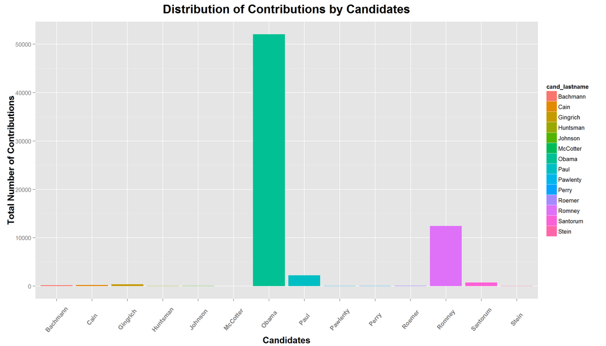

#### Observations and questions from the distribution of contributions by candidates

- Obama had the highest number of contributions which is total of 52072.
- Being winner Obama getting highest number contributions is not very surprising but did he get highest amount as well? It would be interesting to know.
- Romney who was his close competitor comes far second. There is huge difference in the number of contributions what Romney got compared to Obama. Is it because of the number of candidates being more from Romney’s Republican party? Did the Republican party contributions got divided between the large number of candidates?
- McCotter has the least with only one contribution.

#### How did the distribution of the contribution vary by Parties? Did the winning party get the highest number of contributions?

```
##
##                    Democratic Party                         Green Party
##                               52072                                  46
##                   Libertarian Party                    Republican Party
##                                  60                               16340
## Republican,Reform & Americans Elect
##                                  85
```

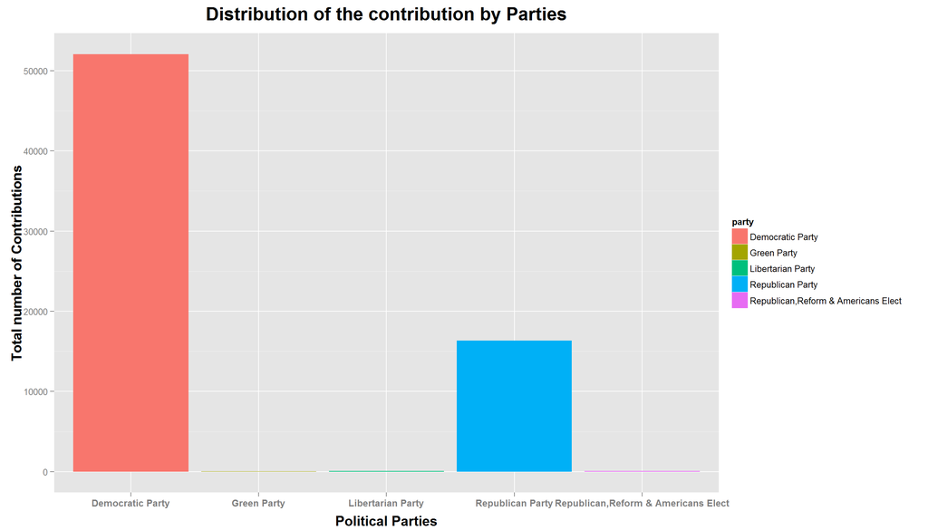

#### Observations and questions from the distribution of contributions by parties

- Democratic party has the highest number of contributions with Republican Party coming second.
- This is not very surprising as they are the major political parties and top two contenders.
- Obama being the only candidate of the Democratic Party has same number of contributions as his party
- Republican party had 10 candidates from the time the election started and got way less number of contributions than Democratic Party.
- Given the number of candidates Republican Party had, they should have got more than what they ended up.
- It would be interesting to know if the huge difference in the number of contributions between the top two parties really have the same difference when it comes to the amount contributed?
- One more surprise is one candidate was the nominee of three different parties during 2012 elections.

#### How is the distribution of contributions among Top 10 Cities? Which city contributed the most and which came second?

```
## [1] 796   2
```

```
## Source: local data frame [10 x 2]
##
##    contbr_city count
## 1      MADISON 10703
## 2    MILWAUKEE  7793
## 3       RACINE  1391
## 4    MIDDLETON  1298
## 5    GREEN BAY  1201
## 6     WAUKESHA  1179
## 7       MEQUON  1076
## 8   EAU CLAIRE  1068
## 9   BROOKFIELD  1066
## 10     KENOSHA  1048
```

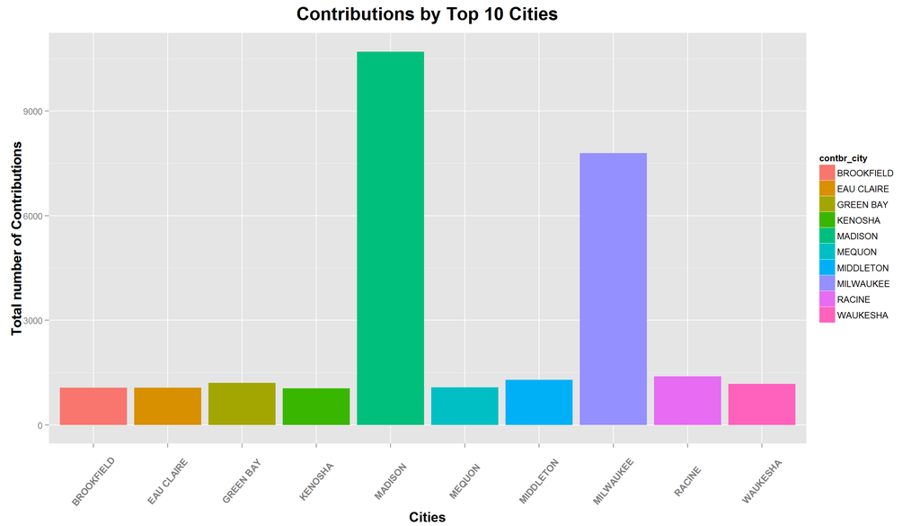

#### Observations and questions from the distribution of contributions by top 10 cities

- Madison is the city with highest number of contributions with Milwaukee coming close second.
- Madison being the capital city has the highest contributions.
- Milwaukee being the biggest city in state has the second highest number of contributions
- Kenosha comes at 10th place.
- The number of contributions from top 2 cities is more than the contributions from rest of the 8 cities in top 10.
- This clearly shows the key role played by the people from the top contributing cities
- It would be interesting to know how these cities contributed for each party and candidate.

#### How is the Distribution of records among Bottom 10 Cities? Which city contributed the least?

```
## Source: local data frame [10 x 2]
##
##     contbr_city count
## 1  W MILWAAUKEE     1
## 2      WACKESHA     1
## 3      WAWATOSA     1
## 4      WESTBORO     1
## 5    WHITE LAKE     1
## 6       WILLARD     1
## 7     WILWAUKEE     1
## 8    WITTENBERG     1
## 9       WUKESHA     1
## 10        ZENDA     1
```

#### Observations from the distribution of records by bottom 10 cities

- One interesting thing after checking the least contributing cities is the data is not fully cleaned.
- There are certain city names which seems to be typed into the dataset wrongly. Example: There is a city with the recorded name as “W MILWAAUKEE” which is definitely for Milwaukee. Going by this it looks like there is a need to clean the data set for the city names.
- There is need to check and clean the data set further but since it is out of scope of the project ignoring it for now.
- All least contributing cities have only one contribution.

#### How is the distribution of the contributions by Zip Code?

```
## Source: local data frame [10 x 2]
##
##    contbr_zip count
## 1       53711  2960
## 2       53705  2447
## 3       53211  1931
## 4       53217  1504
## 5       53704  1435
## 6       53562  1297
## 7       53202  1212
## 8       53703  1077
## 9       53092  1002
## 10      53717   899
```

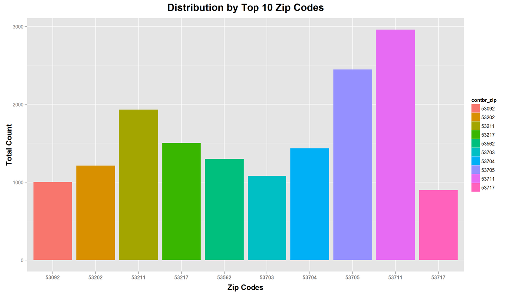

#### Observations from the distribution of the contributions by top 10 zip codes

- 53711 zip code has the highest number of contributions. As expected its the zip code of Madison which is city with highest number of contributions.
- Even the top second zip code belongs to Madison city.
- Third and fourth belong to Milwaukee which is the city with second highest number of contributions.

#### How is the distribution of the contributions by Occupation? People from which profession contributed the most for the elections? What are the other occupations of the top contributors?

```
## [1] 4138    2
```

```
## Source: local data frame [10 x 2]
##
##                         contbr_occupation count
## 1                                 RETIRED 19318
## 2                               PHYSICIAN  1935
## 3                   INFORMATION REQUESTED  1731
## 4  INFORMATION REQUESTED PER BEST EFFORTS  1635
## 5                                ATTORNEY  1623
## 6                                 TEACHER  1589
## 7                               HOMEMAKER  1517
## 8                               PROFESSOR  1304
## 9                            NOT EMPLOYED   800
## 10                               ENGINEER   701
```

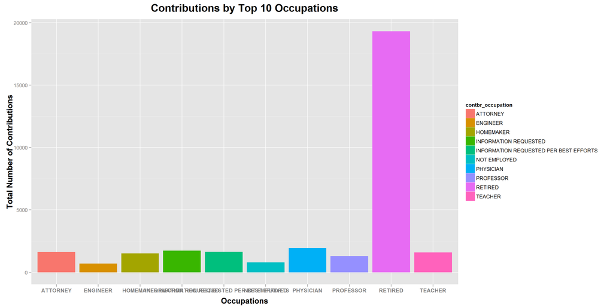

#### Observations and questions from the contributions by top 10 occupations

- There are 4138 occupations mentioned in the dataset
- Retired people are the highest contributors.
- Physicans are second highest contributors
- Third and fourth are those who have not provided the occupation name. This goes to show lot of people do not give their occupation details.
- Surprising thing coming out of this is people who are retired are more interested in the politics and government than others. Also it is really surprising how did all these retired people got to spend so much on the elections without worrying about their retired life.
- With Homemakers and Not Employed also making it to the top 10 occupations, its very surprising how people who are not in regular jobs contributing so much to the elections.

#### How is the distribution of the contributions by Contributors?

```
## Source: local data frame [10 x 2]
##
##           contbr_nm count
## 1  ANDERSON, TERESA    98
## 2     VOLZ, WILLIAM    88
## 3   SILVERMAN, CARL    83
## 4         KURTH, ED    74
## 5    PORASIK, NANCY    71
## 6   OXHOLM, BARBARA    70
## 7  BURDICK, DOLORES    68
## 8  MINNICH, LOIS E.    68
## 9   GIOVANNI, SUSAN    67
## 10    HAACK, ROBERT    67
```

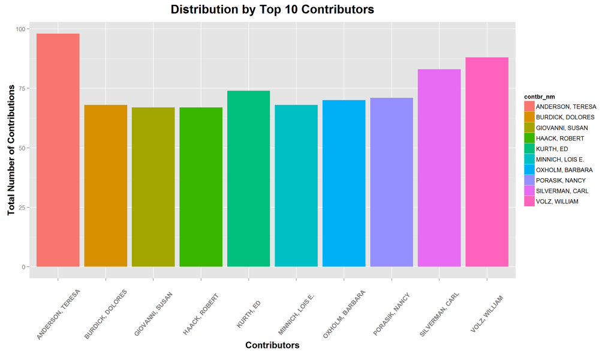

#### Observations from the distribution of the data by contributors

- ANDERSON, TERESA contributed 98 times.
- VOLZ, WILLIAM contributed 88 times.

Below table shows repeated contributions::

```
##
##    1    2    3    4    5    6    7    8    9   10   11   12   13   14   15
## 7384 3899 2133 1330  932  632  502  346  256  229  187  134  115  100   90
##   16   17   18   19   20   21   22   23   24   25   26   27   28   29   30
##   75   65   45   31   33   36   26   26   18   12   18   23    8   11   12
##   31   32   33   34   35   36   37   38   39   40   41   42   43   44   45
##    9    4    3   16   15    7    4    5    8    2    1    3    3    2    4
##   46   47   48   49   50   51   53   54   55   56   58   60   63   67   68
##    3    2    6    1    1    1    1    4    4    2    1    2    2    2    2
##   70   71   74   83   88   98
##    1    1    1    1    1    1
```

- Thousands of people have contributed more than once. Example: 3899 individuals have contributed twice
- Major percentage have contributed more than once.
- Since the there is no unique identifier for the contributors it would be difficult to find number of contributions by unique users as names can be same for lot of people.

#### How many contributions has the female candidate got and how is the distribution by gender?

```
##
## Female   Male
##    195  68408
```

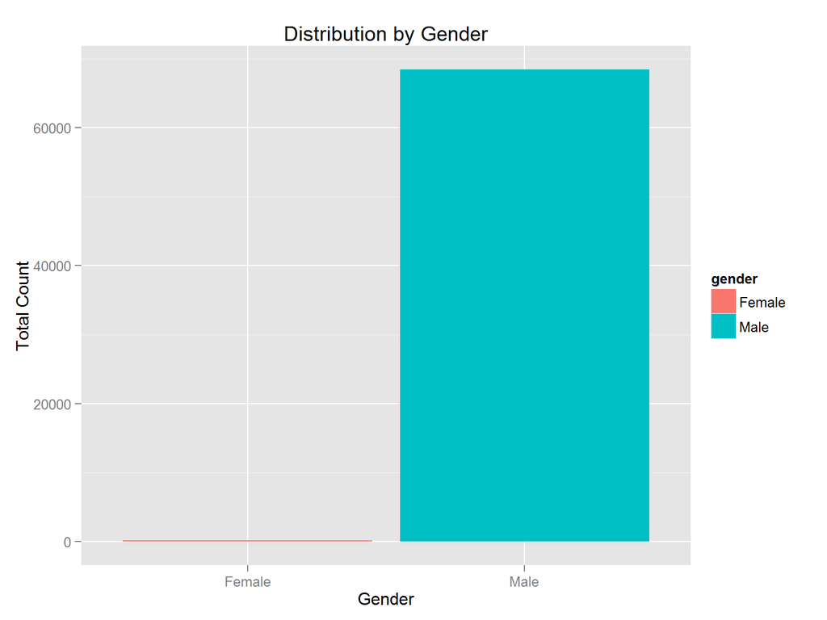

#### Observations from the distribution of the data by gender

- With only one female candidate and someone who was not major candidate, the number of contributions is very very less compared to the male candidates.
- This is not surprising as there are total of 14 candidates and among which only one is female.

#### Proportion of contributions by gender

```
##
##      Female        Male
## 0.002842441 0.997157559
```

#### How contribution varies over time?

```
## [1] "2011-01-01"
```

```
## [1] "2012-12-31"
```

[output not shown]

[output cut: 154 more lines]

```
##        717        616        759        892        660       1214
## 2012-11-01 2012-11-02 2012-11-03 2012-11-04 2012-11-05 2012-11-06
##       1029       1454        640        935        256        159
## 2012-11-07 2012-11-08 2012-11-09 2012-11-12 2012-11-13 2012-11-14
##          9          7         10          4          5          5
## 2012-11-15 2012-11-17 2012-11-18 2012-11-19 2012-11-20 2012-11-23
##          4          3          1         10          1          2
## 2012-11-26 2012-11-28 2012-11-29 2012-12-01 2012-12-02 2012-12-03
##          2          8          1          4          1          1
## 2012-12-06 2012-12-10 2012-12-11 2012-12-12 2012-12-13 2012-12-14
##          1          2          9          2          1          1
## 2012-12-15 2012-12-16 2012-12-17 2012-12-18 2012-12-19 2012-12-26
##          2          1          2          2          2          1
## 2012-12-31
##          1
```

```
## stat_bin: binwidth defaulted to range/30. Use 'binwidth = x' to adjust this.
```

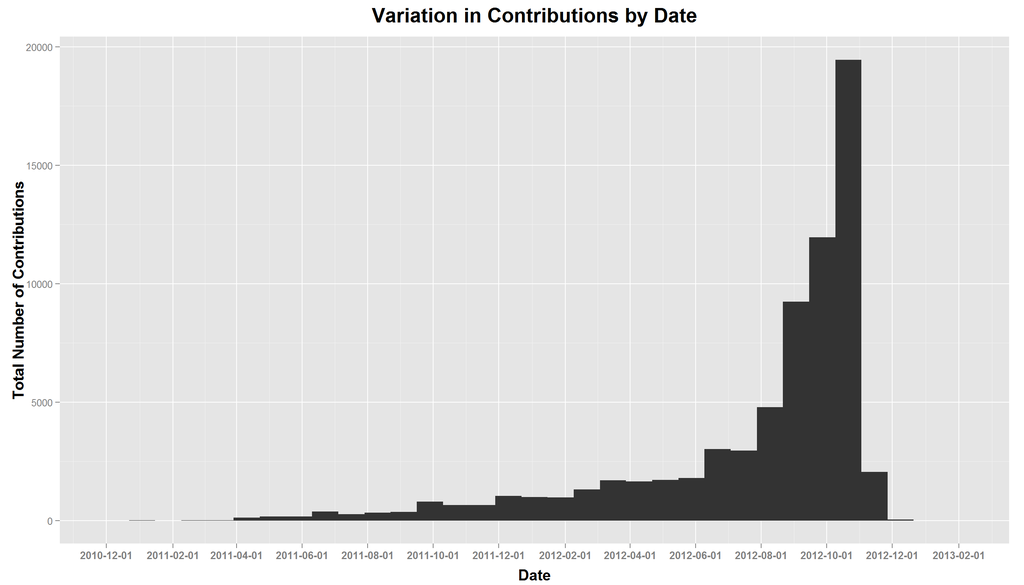

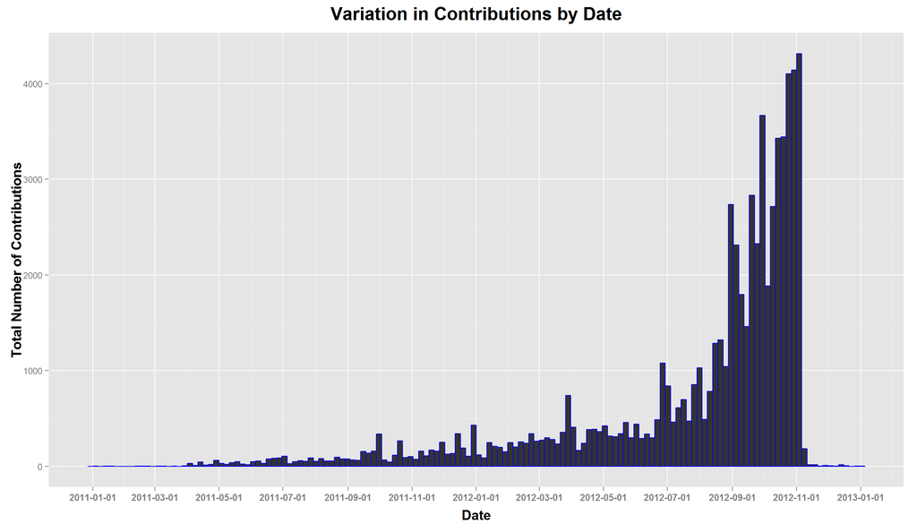

#### Observations from the distribution and variation of the contributions over time:

- Contributions for the elections of 2012 started on 2011-01-01 and 2012-12-31
- One thing to notice going by dates is contributions were given even after the elections day
- There is exponential increase in the number of contributions as the elections near.
- Most contributions are during the last few months before the election day.
- This seems to be when the fight for the Presidential post is finally between the two contendors.
- Major number of contributions coming between September 2012 to November 2012

# Univariate Analysis

### What is the structure of your dataset?

- There are 69304 observations with 18 variables in the dataset.
- For exploration of the dataset observations with negative contributions were removed and also 4 new variables were added. Hence the new observations value is 68603 with 22 variables.
- All are categorical variables except the contb_receipt_amt and file_num variables.

Some of the other observations:

- Barack Obama is the candidate with highest number of contributions.
- City of Madison has highest number of contributions with Milwaukee coming second.
- Retired people are highest contributors by occupation
- Least amount contributed is negative -5000 and maximum is 7500.
- Negative values were refunds and other deductions so had to remove from the dataset for analysing the contributions
- Democratic Party getting the highest number of contribution with Republican party second by huge difference.
- There is only one female candidate with less contributions.
- Major number of contributions coming between September 2012 to November 2012

### What is/are the main feature(s) of interest in your dataset?

contb_receipt_amt, cand_nm, contbr_city, party, gender and contb_receipt_dt

Here the most interesting question is how all of these variables contributed in the variation in the amount contributed to the elections and how did it play a major role in deciding the winner.

### What other features in the dataset do you think will help support your investigation into your feature(s) of interest?

contbr_occupation could be one more variable which could help.

### Did you create any new variables from existing variables in the dataset?

Below variables were created:

- party - Political party of the candidate
- gender - Gender of the candidates.
- cand_firstname - First name of the candidate
- cand_lastname - Last name of the candidate

### Of the features you investigated, were there any unusual distributions? Did you perform any operations on the data to tidy, adjust, or change the form of the data? If so, why did you do this?

Firstly there were negative values for the contb_receipt_amt variable. When digged into it found that they were related to the refunds made by the party to the contributors who had contributed in 2008 as well as some other adjustments made during 2012 elections. There were removed for analysing the dataset.

Also cleaned the contbr_zip variable value to include only the 5 digit zip code as the original values had subcodes also for lot of entries.

# Bivariate Plots Section

### Explore how the contribution of the amount varies for candidates.

```
## contributions$cand_lastname: Bachmann
##    Min. 1st Qu.  Median    Mean 3rd Qu.    Max.
##      13      50     100     166     250    2000
## --------------------------------------------------------
## contributions$cand_lastname: Cain
##    Min. 1st Qu.  Median    Mean 3rd Qu.    Max.
##     5.0   100.0   250.0   497.1   500.0  2500.0
## --------------------------------------------------------
## contributions$cand_lastname: Gingrich
##    Min. 1st Qu.  Median    Mean 3rd Qu.    Max.
##     5.0    50.0   100.0   257.1   250.0  5000.0
## --------------------------------------------------------
## contributions$cand_lastname: Huntsman
##    Min. 1st Qu.  Median    Mean 3rd Qu.    Max.
##     3.0    25.0   100.0   523.1   300.0  2500.0
## --------------------------------------------------------
## contributions$cand_lastname: Johnson
##    Min. 1st Qu.  Median    Mean 3rd Qu.    Max.
##    10.0    25.0   100.0   147.5   112.8  1000.0
## --------------------------------------------------------
## contributions$cand_lastname: McCotter
##    Min. 1st Qu.  Median    Mean 3rd Qu.    Max.
##     100     100     100     100     100     100
## --------------------------------------------------------
## contributions$cand_lastname: Obama
##    Min. 1st Qu.  Median    Mean 3rd Qu.    Max.
##     1.0    20.0    50.0   100.2   100.0  5000.0
## --------------------------------------------------------
## contributions$cand_lastname: Paul
##    Min. 1st Qu.  Median    Mean 3rd Qu.    Max.
##    1.32   25.00   70.00  121.40  101.20 2500.00
## --------------------------------------------------------
## contributions$cand_lastname: Pawlenty
##    Min. 1st Qu.  Median    Mean 3rd Qu.    Max.
##    30.0   100.0   150.0   777.1  1000.0  5000.0
## --------------------------------------------------------
## contributions$cand_lastname: Perry
##    Min. 1st Qu.  Median    Mean 3rd Qu.    Max.
##    10.0   100.0   250.0   334.9   250.0  2500.0
## --------------------------------------------------------
## contributions$cand_lastname: Roemer
##    Min. 1st Qu.  Median    Mean 3rd Qu.    Max.
##    5.00   25.00   50.00   57.84  100.00  100.00
## --------------------------------------------------------
## contributions$cand_lastname: Romney
##    Min. 1st Qu.  Median    Mean 3rd Qu.    Max.
##     3.0    55.0   150.0   405.2   300.0  7500.0
## --------------------------------------------------------
## contributions$cand_lastname: Santorum
##    Min. 1st Qu.  Median    Mean 3rd Qu.    Max.
##      10      50     100     203     200    5000
## --------------------------------------------------------
## contributions$cand_lastname: Stein
##    Min. 1st Qu.  Median    Mean 3rd Qu.    Max.
##     3.0    50.0   100.0   175.7   250.0  1000.0
```

```
## contributions$cand_lastname: Bachmann
## [1] 32365
## --------------------------------------------------------
## contributions$cand_lastname: Cain
## [1] 127267.9
## --------------------------------------------------------
## contributions$cand_lastname: Gingrich
## [1] 100282.5
## --------------------------------------------------------
## contributions$cand_lastname: Huntsman
## [1] 17263
## --------------------------------------------------------
## contributions$cand_lastname: Johnson
## [1] 8847.92
## --------------------------------------------------------
## contributions$cand_lastname: McCotter
## [1] 100
## --------------------------------------------------------
## contributions$cand_lastname: Obama
## [1] 5215876
## --------------------------------------------------------
## contributions$cand_lastname: Paul
## [1] 274248.1
## --------------------------------------------------------
## contributions$cand_lastname: Pawlenty
## [1] 24090
## --------------------------------------------------------
## contributions$cand_lastname: Perry
## [1] 11385
## --------------------------------------------------------
## contributions$cand_lastname: Roemer
## [1] 4916.12
## --------------------------------------------------------
## contributions$cand_lastname: Romney
## [1] 5030552
## --------------------------------------------------------
## contributions$cand_lastname: Santorum
## [1] 147616.7
## --------------------------------------------------------
## contributions$cand_lastname: Stein
## [1] 8083.5
```

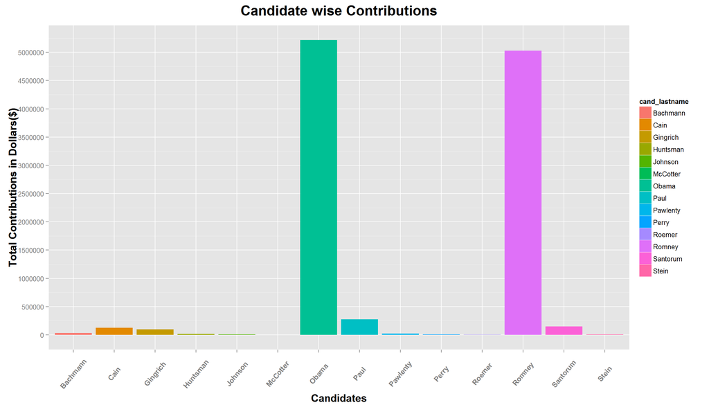

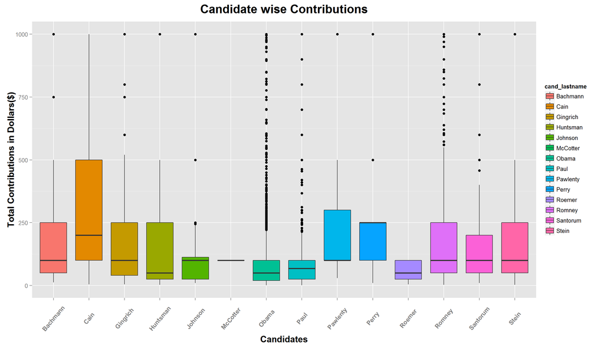

```
## contributions$cand_lastname: Bachmann
## [1] 200
## --------------------------------------------------------
## contributions$cand_lastname: Cain
## [1] 400
## --------------------------------------------------------
## contributions$cand_lastname: Gingrich
## [1] 200
## --------------------------------------------------------
## contributions$cand_lastname: Huntsman
## [1] 275
## --------------------------------------------------------
## contributions$cand_lastname: Johnson
## [1] 87.7775
## --------------------------------------------------------
## contributions$cand_lastname: McCotter
## [1] 0
## --------------------------------------------------------
## contributions$cand_lastname: Obama
## [1] 80
## --------------------------------------------------------
## contributions$cand_lastname: Paul
## [1] 76.25
## --------------------------------------------------------
## contributions$cand_lastname: Pawlenty
## [1] 900
## --------------------------------------------------------
## contributions$cand_lastname: Perry
## [1] 150
## --------------------------------------------------------
## contributions$cand_lastname: Roemer
## [1] 75
## --------------------------------------------------------
## contributions$cand_lastname: Romney
## [1] 245
## --------------------------------------------------------
## contributions$cand_lastname: Santorum
## [1] 150
## --------------------------------------------------------
## contributions$cand_lastname: Stein
## [1] 200
```

#### Observations and questions by exploring the variation in the amount contributed for different candidates:

- Obama had the maximum amount of contribution.
- Romney had the second highest contribution.
- Its very surprising too see the difference in contributed amount between Obama and Romney top two candidates. The difference in number of contributions was too big between them.
- What is the reason behind this? It would be interesting to know.
- Inspite of 9 other contendors from his own party, Romney still comes close second to Obama which is very surprising. If there were few competitions from his own party he could have also got more contributions from his party contributors.
- Romney had higher mean contribution than Obama.
- Romney also had 75% of his contributions below $300
- Obama had 3rd quartile least among all candidates
- Pawlenty had the highest mean
- McCotter with least contribution of $100 which was the only contribution he had got.
- Obama had one of the least IQR

### Explore how the contribution of the amount varies for different parties:

```
## contributions$party: Democratic Party
## [1] 5215876
## --------------------------------------------------------
## contributions$party: Green Party
## [1] 8083.5
## --------------------------------------------------------
## contributions$party: Libertarian Party
## [1] 8847.92
## --------------------------------------------------------
## contributions$party: Republican Party
## [1] 5765170
## --------------------------------------------------------
## contributions$party: Republican,Reform & Americans Elect
## [1] 4916.12
```

```
## contributions$party: Democratic Party
##    Min. 1st Qu.  Median    Mean 3rd Qu.    Max.
##     1.0    20.0    50.0   100.2   100.0  5000.0
## --------------------------------------------------------
## contributions$party: Green Party
##    Min. 1st Qu.  Median    Mean 3rd Qu.    Max.
##     3.0    50.0   100.0   175.7   250.0  1000.0
## --------------------------------------------------------
## contributions$party: Libertarian Party
##    Min. 1st Qu.  Median    Mean 3rd Qu.    Max.
##    10.0    25.0   100.0   147.5   112.8  1000.0
## --------------------------------------------------------
## contributions$party: Republican Party
##    Min. 1st Qu.  Median    Mean 3rd Qu.    Max.
##    1.32   50.00  100.00  352.80  250.00 7500.00
## --------------------------------------------------------
## contributions$party: Republican,Reform & Americans Elect
##    Min. 1st Qu.  Median    Mean 3rd Qu.    Max.
##    5.00   25.00   50.00   57.84  100.00  100.00
```

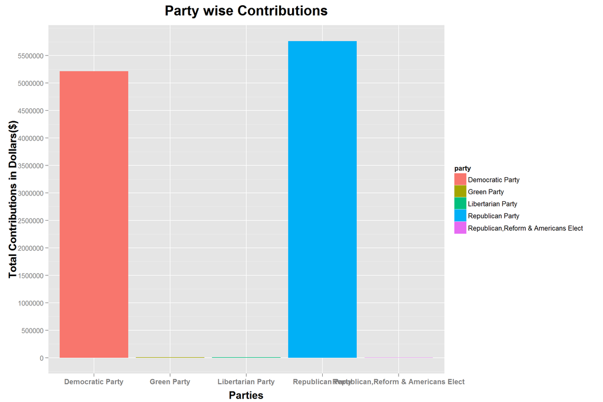

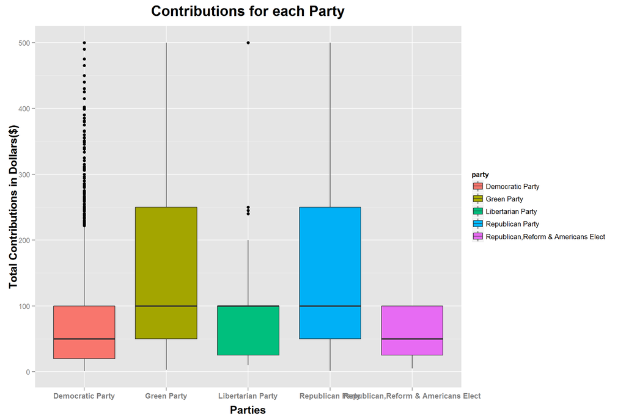

```
## contributions$party: Democratic Party
## [1] 80
## --------------------------------------------------------
## contributions$party: Green Party
## [1] 200
## --------------------------------------------------------
## contributions$party: Libertarian Party
## [1] 87.7775
## --------------------------------------------------------
## contributions$party: Republican Party
## [1] 200
## --------------------------------------------------------
## contributions$party: Republican,Reform & Americans Elect
## [1] 75
```

#### Observations and questions by exploring the variation in the amount contributed for different parties:

- There are people who have contributed even $1
- Republican Party had got the maximum contributions.
- Republican party had also got the highest individual contribution of $7500.
- Even mean contribution is highest for Republican party
- Democratic Party coming close second
- The Republican,Reform Party & Americans Elec which three parties combined of a candidate has the least contribution with 4916.12. It would have been got if we had got the information on how this distribution for that candidate varies for each party.
- As we thought earlier if Romney was the only candidate from Republican Party he would have got more contributions in terms of money than Obama as Republicans got more amount of contributions than Democrats.
- Party should have control on fielding the candidates as having too much competitions within the party might affect the chances.
- Republicans had the highest IQR and Democrats had one of the least.

#### What are the top 10 contributing cities by amount?

```
## Source: local data frame [10 x 2]
##
##    contbr_city     total
## 1      MADISON 1499830.0
## 2    MILWAUKEE 1274665.3
## 3       MEQUON  306436.5
## 4   BROOKFIELD  299231.0
## 5     HARTLAND  279320.7
## 6    MIDDLETON  224123.5
## 7    GREEN BAY  193107.8
## 8   JANESVILLE  191700.6
## 9     WAUKESHA  173895.0
## 10      RACINE  163240.8
```

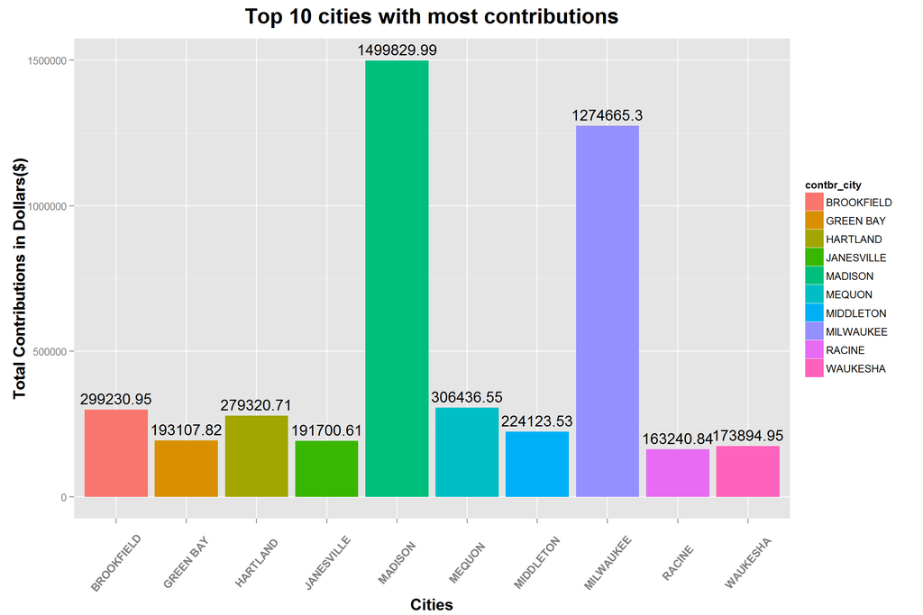

```
## Source: local data frame [10 x 2]
##
##        contbr_city total
## 1           GILMAN  44.0
## 2        WILWAUKEE  40.0
## 3          CAMERON  35.0
## 4          LORETTA  35.0
## 5  MEROMONOE FALLS  35.0
## 6      SILVER LAKE  30.0
## 7       OCONOMOOWC  25.0
## 8      SCANDINAVIA  25.0
## 9       VILLA PARK  24.5
## 10          DUPONT  14.0
```

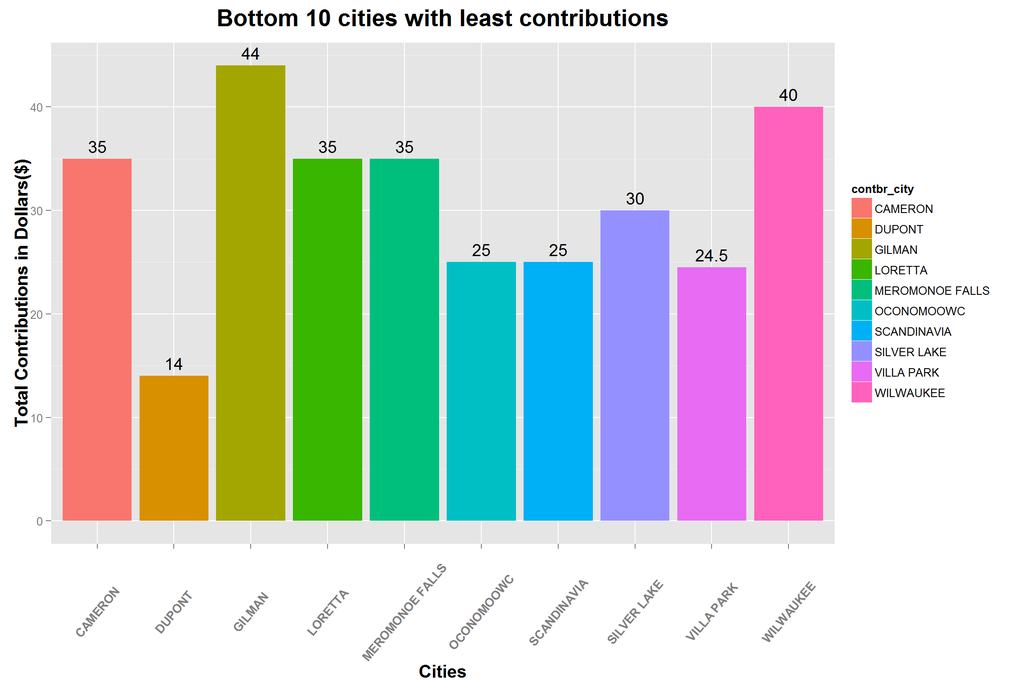

#### Observations and questions by exploring the top 10 and bottom 10 contributing cities::

- Madison has made the highest contribution among all the cities which is $1499830.0
- Milwaukee has the second highest contribution which is $1274665.3
- DUPONT has made the least contribution of just $14
- There is a city called Wilwaukee which seems to be wronly mentioned
- Difference between the contribution of the top two cities and the rest seems to be way too high.
- It would be interesting to know how these cities have contributed in the last few elections.
- It would also be interesting to know how these cities contributed for each party.
- Which city contributed more for which candidate and party?
- One more thing visible is the cities names is not cleaned as observed during univariate analysis

### How does the contribution vary with time?

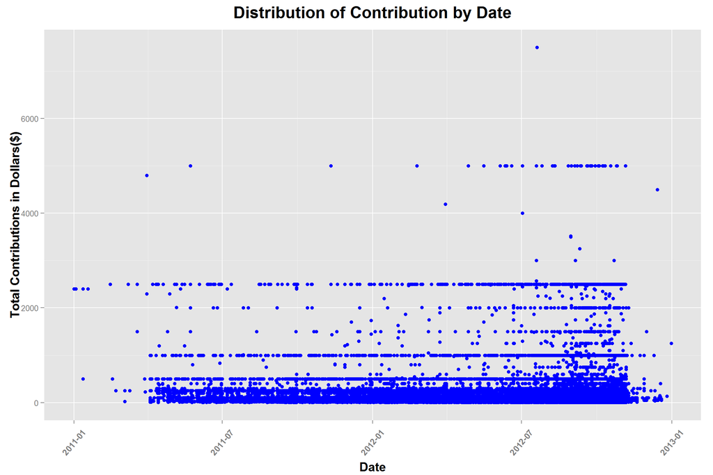

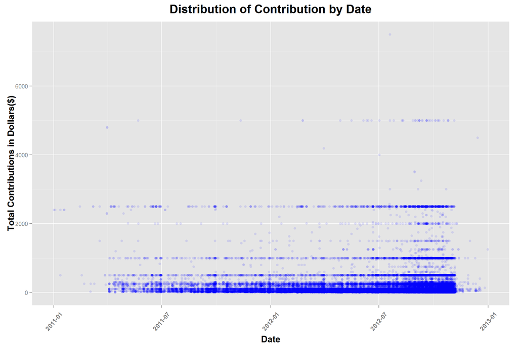

```
##    Min. 1st Qu.  Median    Mean 3rd Qu.    Max.
##     1.0    25.0    50.0   160.4   100.0  7500.0
```

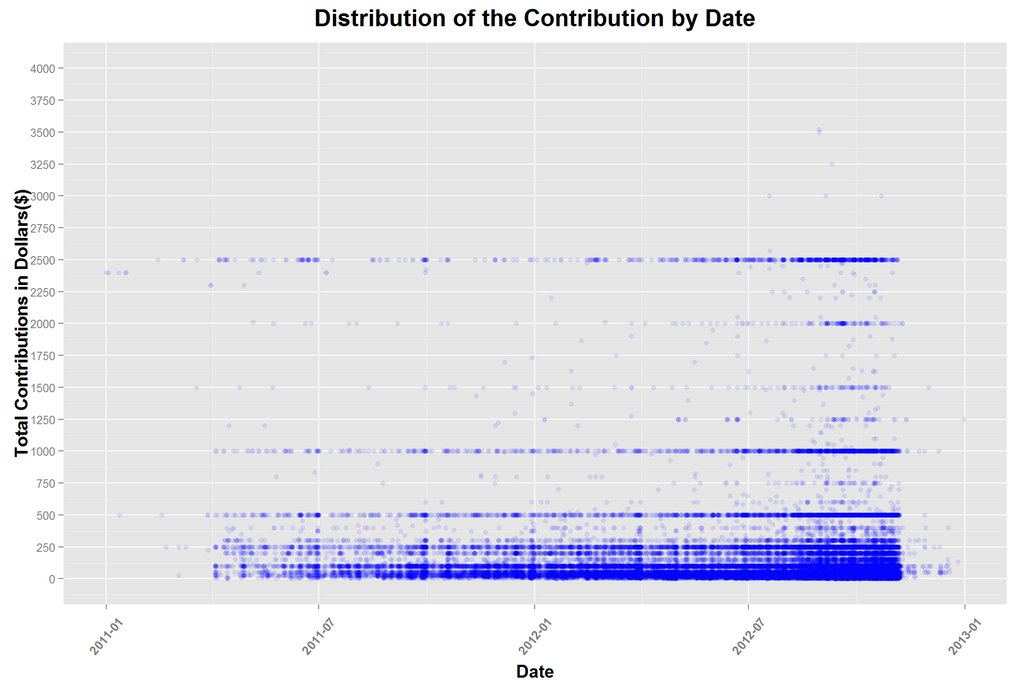

```
##
##     1     2     3     4     5     6     7     8     9    10    11    12
##     4    70   247   264   691   304    42   321    26  3519   285   106
##    13    14    15    16    17    18    19    20    21    22    23    24
##   177  1753  2408    22    92   202  2041  1777    22    75    18    33
##    25    26    27    28    29    30    31    32    33    34    35    36
##  6156    40    42    34    18   682   153    30    16    43  5790    41
##    37    38    39    40    41    42    43    44    45    46    47    48
##    19    42     4   412    44    74     1    44   147    14    16    31
##    49    50    51    52    53    54    55    56    57    58    59    60
##    12  8302    71    30    15    25  1112  1049    11    25    10   265
##    61    62    63    64    65    66    67    68    69    70    71    72
##     4    62    13     5    60    17    10    38     3   108    15    13
##    73    74    75    76    77    78    79    80    81    82    83    84
##     7     9   772    25     4    11     6    58     7    20     7    11
```

[output cut: 64 more lines]

#### Observations by exploring the variation in the amount contributed by time:

- 75% of the contributions are less than $100
- There are people who have contributed even $1
- Majority of the contributions are less than 300 dollars
- 10,15,25,50,100,150,200,250,500,1000,2500 are the most commmonly contributed amounts by individuals.
- There are 6156 number of contributions of $25
- There are 11795 number of contributions of $100
- There are 3519 number of contributions of $10
- One surprise is there are contributions even after the elections which was held in Nov 2012. These contributions are till Jan 2013 when the President took the oath.

#### How much contributions has the female candidate got and how is the distribution by gender?

```
## contributions$gender: Female
## [1] 0.002941499
## --------------------------------------------------------
## contributions$gender: Male
## [1] 0.9970585
```

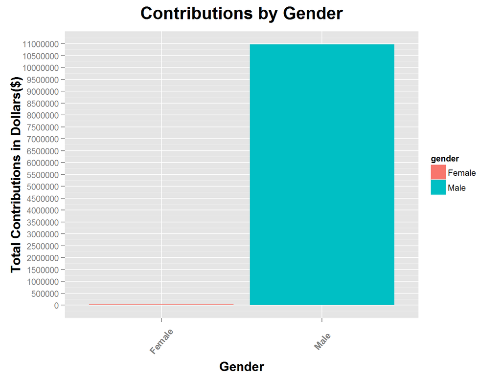

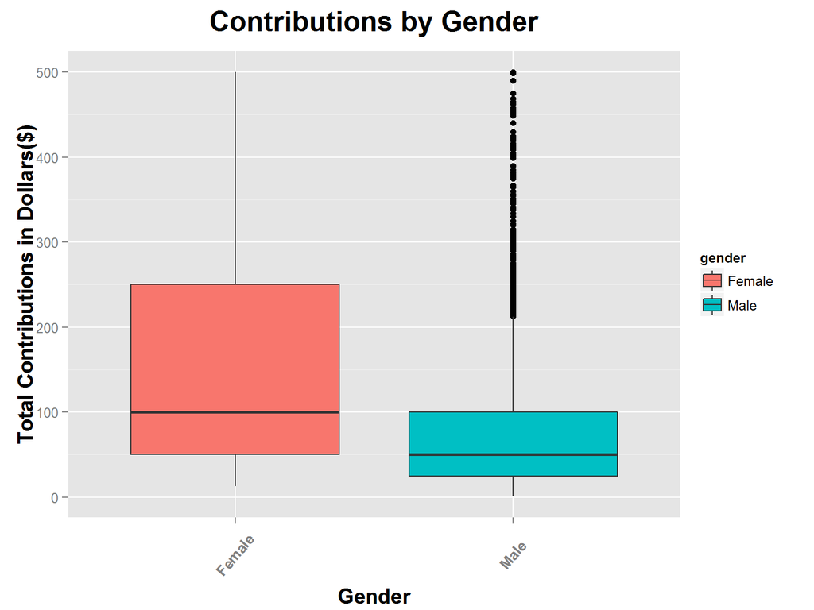

```
## contributions$gender: Female
##    Min. 1st Qu.  Median    Mean 3rd Qu.    Max.
##      13      50     100     166     250    2000
## --------------------------------------------------------
## contributions$gender: Male
##    Min. 1st Qu.  Median    Mean 3rd Qu.    Max.
##     1.0    25.0    50.0   160.4   100.0  7500.0
```

```
## contributions$gender: Female
## [1] 32365
## --------------------------------------------------------
## contributions$gender: Male
## [1] 10970528
```

```
## contributions$gender: Female
## [1] 200
## --------------------------------------------------------
## contributions$gender: Male
## [1] 75
```

#### Observations by exploring the variation in the contribution by gender:

- There is huge difference between the amount contributed to male candidates and female candidate which is not unexpected given the number of candidates and ratio of candidates by gender
- Male candidates got $10970528 and female candidate got $32365
- 99.7% of the contributions were for the male candidates and the rest for the only female candidate
- Maximum individual contribution for a male is $7500 and for a female is $2000
- Mean contribution for a male is $160.4 and for a female is $166
- 75% of the individuals contributions made are less than $100 for male and $250 dollars for female.
- IQR for female is $200 and for male is $75

#### People from which occupation contributed the highest amounts

```
## Source: local data frame [10 x 2]
##
##                         contbr_occupation     total
## 1                                 RETIRED 2621425.9
## 2  INFORMATION REQUESTED PER BEST EFFORTS  851455.8
## 3                               PHYSICIAN  462159.9
## 4                               HOMEMAKER  449276.6
## 5                                ATTORNEY  384270.3
## 6                   INFORMATION REQUESTED  318200.2
## 7                               PRESIDENT  205037.3
## 8                               PROFESSOR  174822.5
## 9                               EXECUTIVE  162863.0
## 10                         BUSINESS OWNER  146489.2
```

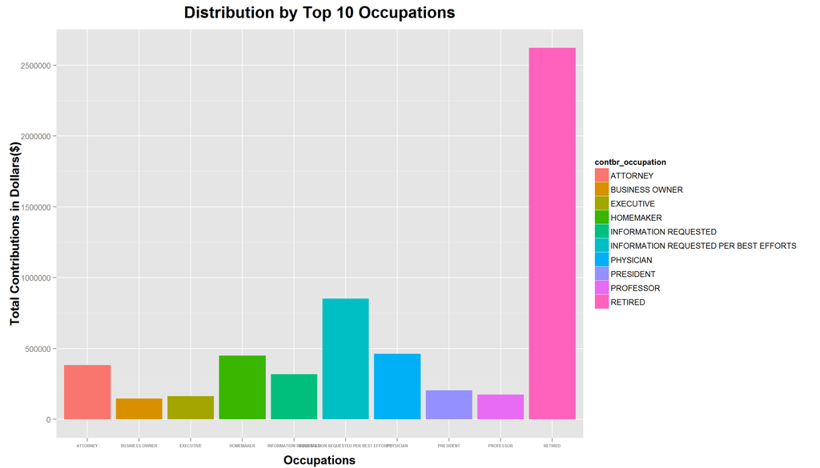

# Bivariate Analysis

### Talk about some of the relationships you observed in this part of the investigation. How did the feature(s) of interest vary with other features in the dataset?

- Even though Obama from democratic party won the election it was the Republican Party which got more contribution in terms of money.
- There is huge difference between the money contributed to female candidate and the male candidates. But this is not surpricing given the ratio of the candidates by gender.
- There is huge spike in the amounts contributed as the election approaches. It is during this period majority of the people decide whom to vote. This should be a lesson for all the contending parties to make sure their campaigns are better during the final few months which is a decider.
- Highest contribution by cities comes from the capital city and the largest city in the state.
- Also it is very surprising to see that people who are not in job like Retired and home makers are top contributors.

### Did you observe any interesting relationships between the other features (not the main feature(s) of interest)?

- Contribution by occupation is very surprising given the highest total contribution coming from the retired as well as home makers and not to forget the people who have not mentioned their occupation.

### What was the strongest relationship you found?

Since there is only one numerical variable in the dataset which is the amount contributed, there is no option to check for strong relationship by plotting scatter plot.

But as per our observation through plotting and summaries there are lot of findings as explanied in the above answers.

# Multivariate Plots Section

#### How does the contribution for the candidates vary by election_tp.

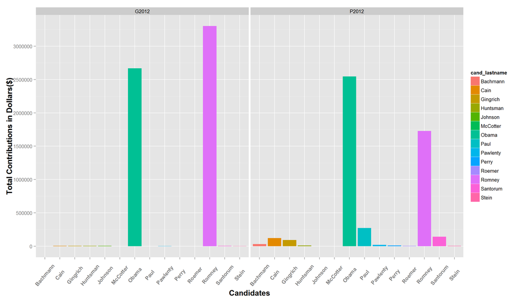

#### Observations:

- Obama had almost similar amount of contributions during both G2012 and P2012
- Romney got twice the amount of contributions during G2012 than in P2012
- This is very surprising as Romney has more contributions during general elections
- Even though Obama had more contributions during the primaries he had lost in terms of contribution to Romney in general elections.
- Also only Obama and Romney had majority of the contributions during G2012 as it they were the only two candidates for G2012.

#### Explore how does the contribution for the parties vary by time, candidate and election type

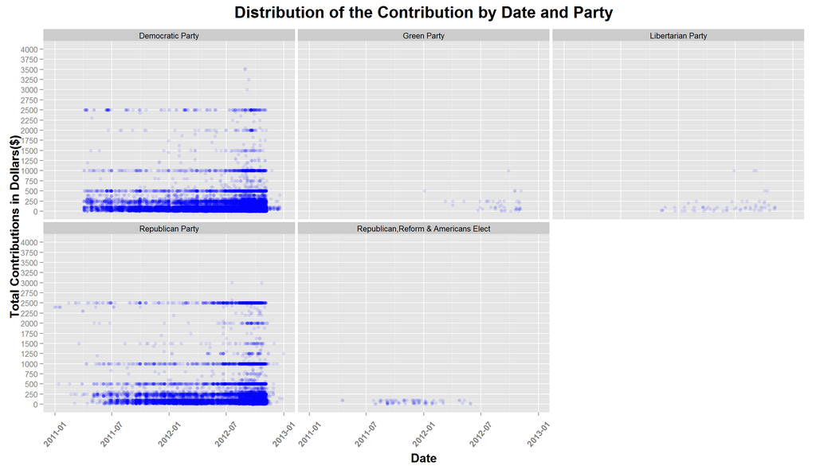

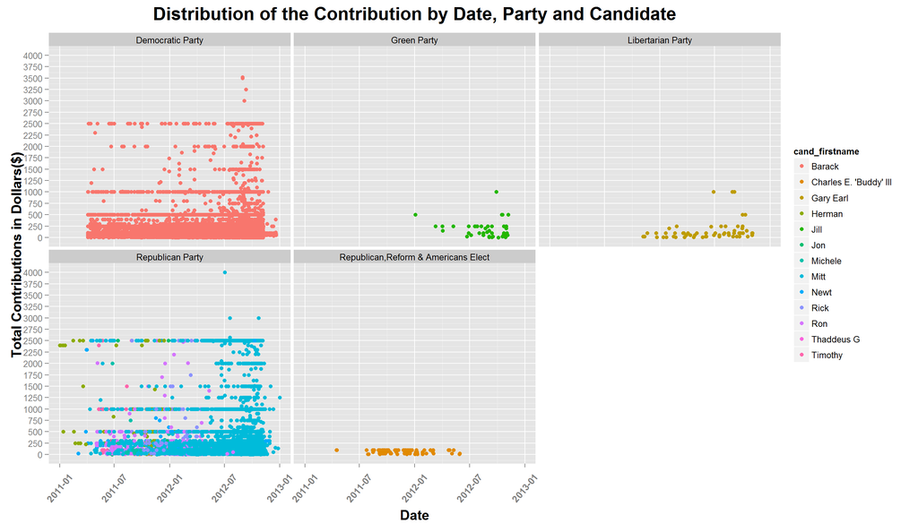

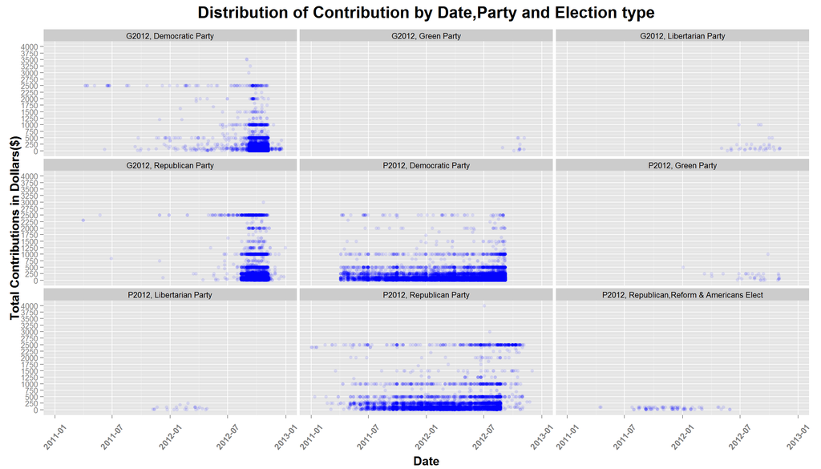

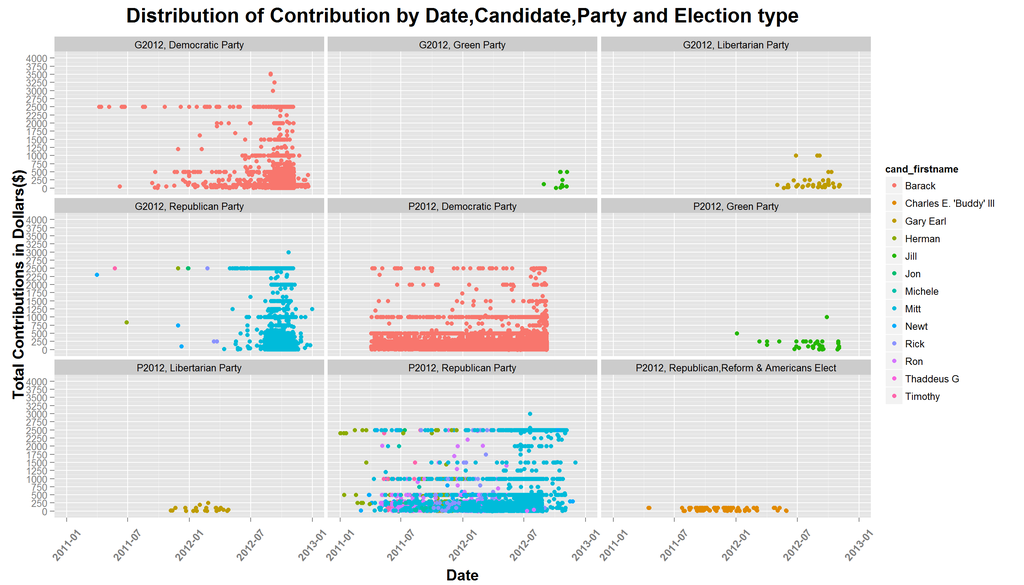

#### Observations after exploring:

- Democratic party has won more number of small contributions which goes to show that they are popular among the common people.
- Republicans have won more number of large contributions which goes to show they are popular among rich people.
- Republicans have the contributions distributed among their lot of candidates but as expected all the candidates had withdrawn from the competition except Romney as the General elections approached.
- Other parties have very less contributions compared to Democratic and Republicans
- When you explore more by grouping the plot based on party and election type, we get to see that the candidate who had stood from three different parties Republican,The Reform Party and Amercian Elect during the course of the elections did not have any contributions during General Elections 2012
- Green party had got contributions during the final months leading to the elections but very neglible.
- It is understandable that other parties got very has the major competition was between the Democratic and Republicans

#### Exlporing the contribution of the amount by Party, Election type and Top 10 Cities

```
## Source: local data frame [6 x 3]
## Groups: party
##
##              party contbr_city      total
## 1 Democratic Party  BROOKFIELD   81180.60
## 2 Democratic Party   GREEN BAY   53703.80
## 3 Democratic Party    HARTLAND   25216.50
## 4 Democratic Party  JANESVILLE   36149.25
## 5 Democratic Party     MADISON 1280783.53
## 6 Democratic Party      MEQUON   88767.00
```

```
## Source: local data frame [6 x 3]
## Groups: party
##
##                                 party contbr_city  total
## 1 Republican,Reform & Americans Elect     MADISON 395.12
## 2 Republican,Reform & Americans Elect      MEQUON  25.00
## 3 Republican,Reform & Americans Elect   MIDDLETON 100.00
## 4 Republican,Reform & Americans Elect   MILWAUKEE 635.00
## 5 Republican,Reform & Americans Elect      RACINE 350.00
## 6 Republican,Reform & Americans Elect    WAUKESHA 100.00
```

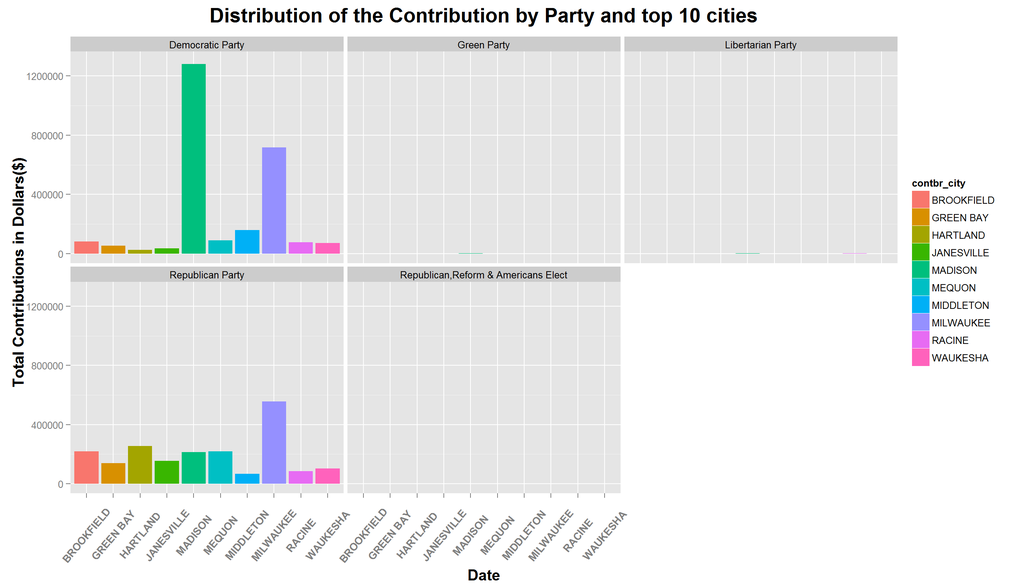

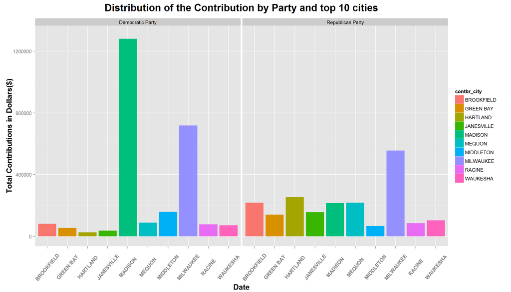

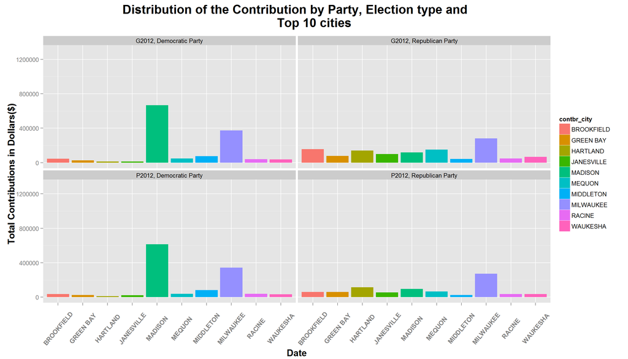